# ClusteringML2

Group 9 - Thomas Trankle, Jaida Clarke, Andrew Tremblay and Jill van den Dungen

3/22/2021

## K-Means

### Create a Simulated Dataset

We begin with a simple simulated example in which there are **truly two clusters** in the data; the first 25 observations have a mean shift relative to the next 25 observations. This makes sure we have to distinct clusters in our data.

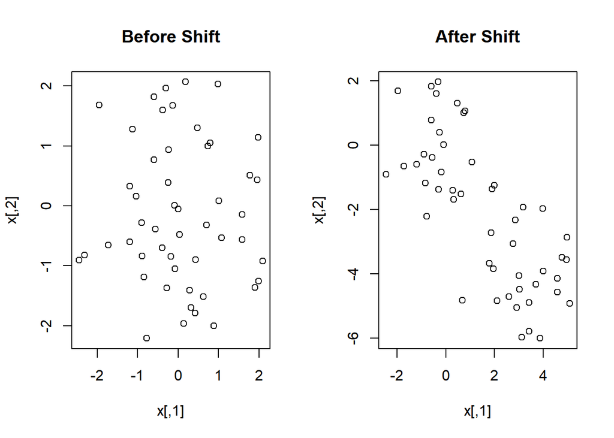

```r
par(mfrow=c(1,2))
set.seed(2)
x <- matrix(rnorm (50*2), ncol=2) # Create a 50 X 2 matrix with samples from a
                               # normal distribution
plot(x, main = 'Before Shift')

x[1:25,1] <- x[1:25,1]+3   # Move half the points 3 units right and
x[1:25,2] <- x[1:25,2]-4   # 4 units down

plot(x,main = 'After Shift')
```

### The Model

To perform *K-Means* clustering we use the function **kmeans()** (built-in with *stats* package).

We now perform *K-means* clustering with K = 2, which is the number of clusters (groups) we want to separate our data into. The number of clusters has to be specified before the model is run. *This is one of the draw backs about K-Means clustering*.

After the model is run, we call the argument km.out$cluster to display the cluster label for each observation in our simulated data set.

```r
km.out <- kmeans (x,2, nstart =20) # kmeans(x, centers, iter.max = 10, nstart = 1,
                                   # algorithm = c("Hartigan-Wong", "Lloyd", "Forgy",
                                   # "MacQueen"), trace=FALSE)

# Display cluster labels assigned to each obs.
km.out$cluster
```

```
##  [1] 1 1 1 1 1 1 1 1 1 1 1 1 1 1 1 1 1 1 1 1 1 1 1 1 1 2 2 2 2 2 2 2 2 2 2 2 2 2
## [39] 2 2 2 2 2 2 2 2 2 2 2 2
```

The K-means clustering perfectly separated the observations into two clusters even though we did not supply any group information to **kmeans()**. We can plot the data, with each observation colored according to its cluster assignment.

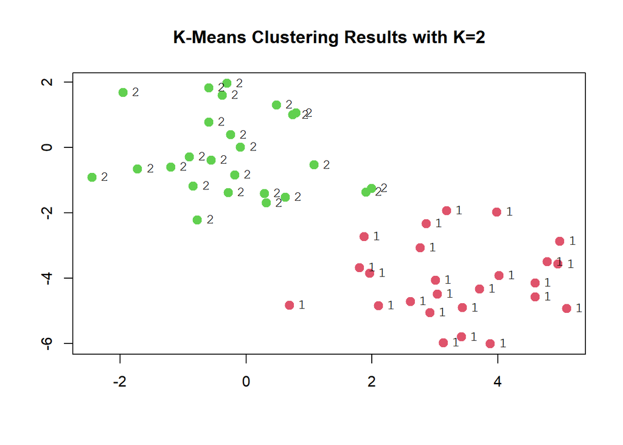

```r
plot(x, col=(km.out$cluster +1),
  main="K-Means Clustering Results with K=2",
  xlab="", ylab="", pch=20, cex=2)
text(x, labels=km.out$cluster,cex=0.9, font=10,pos=4)
```

Here the observations can be easily plotted because they are **two-dimensional**. If there were more than two variables then we could instead perform PCA and plot the first two principal components score vectors.

Alternatively, we can use the **fviz_cluster** function. This provides a nice illustration of the clusters. If there are more than two dimensions (variables) **fviz_cluster** will perform principal component analysis (PCA) and plot the data points according to the first two principal components that explain the majority of the variance. *This function is not in the textbook lab.

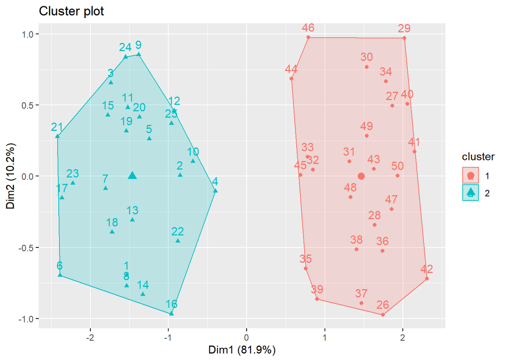

```r
library(factoextra)
set.seed(2)
df <- matrix(rnorm (50*3), ncol=3)   # Create a 50 X 3 matrix

df[1:25,1] <- df[1:25,1]+3
df[1:25,2] <- df[1:25,2]-4
df[1:25,3] <- df[1:25,3]+3

km.out <- kmeans (df,2, nstart =20)
fviz_cluster(km.out, data = df)
```

#### Changing K

In this example, we knew that there really were two clusters because we generated the data. However, for real data, in general we do not know the true number of clusters.

We could instead have performed K-means clustering on this example with K = 3, for example

```r
set.seed(4)
km.out <- kmeans (x,3, nstart = 20)
km.out
```

```
## K-means clustering with 3 clusters of sizes 17, 23, 10
##
## Cluster means:
##         [,1]        [,2]
## 1  3.7789567 -4.56200798
## 2 -0.3820397 -0.08740753
## 3  2.3001545 -2.69622023
##
## Clustering vector:
##  [1] 1 3 1 3 1 1 1 3 1 3 1 3 1 3 1 3 1 1 1 1 1 3 1 1 1 2 2 2 2 2 2 2 2 2 2 2 2 2
## [39] 2 2 2 2 2 3 2 3 2 2 2 2
##
## Within cluster sum of squares by cluster:
## [1] 25.74089 52.67700 19.56137
##  (between_SS / total_SS =  79.3 %)
##
## Available components:
##
## [1] "cluster"      "centers"      "totss"        "withinss"     "tot.withinss"
## [6] "betweenss"    "size"         "iter"         "ifault"
```

When K = 3, *K-means* clustering splits up the two clusters in order try create another distinct group.

[figure not shown]

```r
plot(x, col=(km.out$cluster +1),
  main="K-Means Clustering Results with K=2",
  xlab="", ylab="", pch=20, cex=2)
text(x, labels=km.out$cluster,cex=0.9, font=10,pos=4)
```

### Additional Parameters and Tuning

To run the kmeans() function in R with multiple initial cluster assignments, we use the **nstart** argument. If a value of **nstart** greater than one is used, then K-means clustering will be performed using multiple random assignments in Step 1 of Algorithm 10.1,

**‘K-Means Clustering’** (p.g. 388)

1. *Randomly assign a number, from 1 to K, to each of the observations. These server as initial cluster assignments for the observations.*

and the **kmeans()** function will report only the best results. Here we compare using **nstart=1** to **nstart=20**. We can also think of this as the number of times we wish to perform K-Means Clustering since its based on random initialization.

```r
set.seed(4)
km.out <- kmeans (x, centers = 3, nstart =1) # nstart: if centers is a number how
                                             # many random sets should be chosen?
km.out$tot.withinss
```

```
## [1] 104.3319
```

```r
set.seed(4)
km.out <- kmeans (x, centers = 3, nstart =20)
km.out$tot.withinss
```

```
## [1] 97.97927
```

Note that km.out$tot.withinss is the total within-cluster sum of squares, which we seek to minimize by performing K-means clustering (Equation 10.11).
$$\underset{C_1,\ldots,C_K}{\text{minimize}}\left\{\sum_{k=1}^K\frac{1}{|C_K|}\sum_{i,i' \in C_k} \sum_{j=1}^p(x_{ij}-x_{i'j})^2 \right\}$$

The individual within-cluster sum-of-squares are contained in the vector **km.out$withinss**.

It is recommend to always running *K-means* clustering with a large value of nstart, such as 20 or 50, to minimize the chance of getting a undesirable local optimum. When performing K-means clustering, in addition to using multiple initial cluster assignments, it is also important to set a random seed using the set.seed() function. This way, the initial cluster assignments in Step 1 can be replicated, and the K-means output will be fully reproducible.

#### Tune the optimal number of clusters (k)

Create a vector to store 15 totwithiness scores

```r
kmax <- 15
totwithiness<-rep(0,kmax)
```

Tune k = 1 to 15

```r
for (k in 1:kmax)
{
  totwithiness[k] = kmeans(x,
                           k, # number of clusters
                           nstart=25,
                           iter.max = 15 # maximum number of iterations allowed
                           )$tot.withinss
}
```

Scree plot: tot.withinss by k

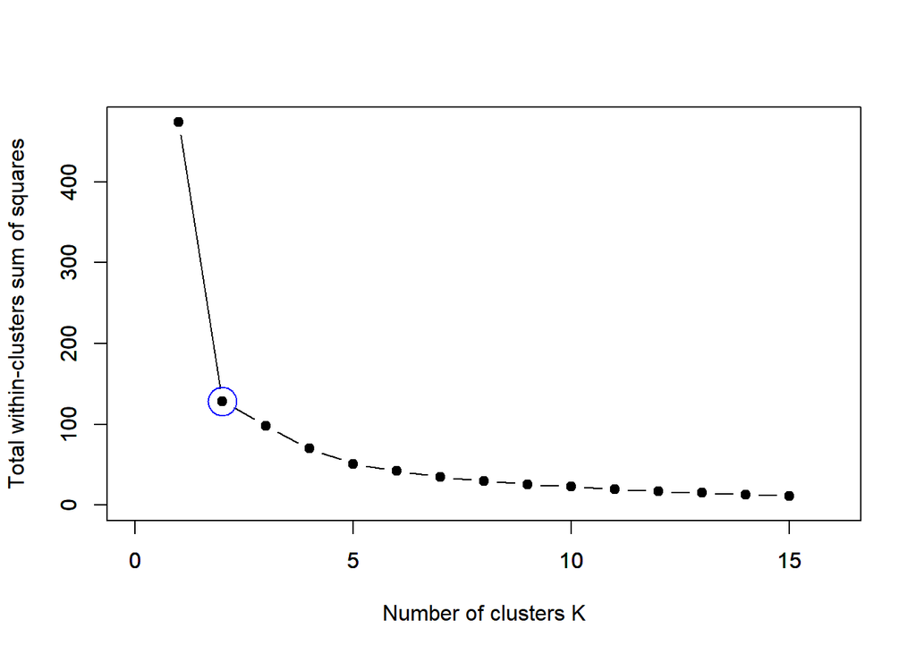

```r
plot(1:kmax, totwithiness,
     type="b", pch = 19, frame = FALSE,
     xlab="Number of clusters K",
     ylab="Total within-clusters sum of squares",
     xlim = c(0,kmax+1),
     ylim = c(0,max(totwithiness)))

# below is just to highlight elbow on graph #
axis(1:kmax)
par(new=TRUE)
plot(2,totwithiness[2], ylim = c(0,max(totwithiness)), xlim = c(0,kmax+1),
     xlab = "", ylab = "", pch = 1, col ="blue", cex = 3)
```

We can also use the **fviz_nbclust()** function to perform this.

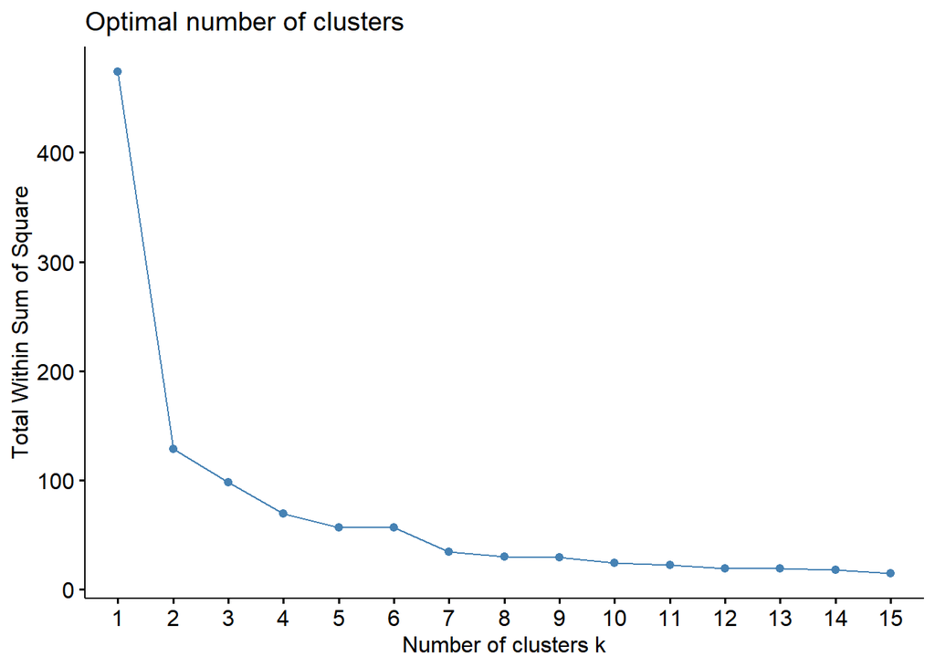

```r
fviz_nbclust(x, kmeans, method = "wss", k.max = 15)
```

## Hierarchical Clustering

The **hclust()** function implements hierarchical clustering in R. In the following example, we use the data from above to plot the hierarchical clustering dendrogram using complete, single, and average linkage clustering, with Euclidean distance as the dissimilarity measure.

We begin by clustering observations using complete linkage. The **dist()** function is used to compute the 50 × 50 inter-observation Euclidean distance matrix.

```r
hc.complete <- hclust(dist(x), method="complete") # tells type of cluster method, type of distance used, and total data points
```

We could just as easily perform hierarchical clustering with average or single linkage instead:

```r
hc.average <- hclust(dist(x), method ="average")
hc.single <- hclust(dist(x), method ="single")
```

We can now plot the dendrograms obtained using the usual **plot()** function.The numbers at the bottom of the plot identify each observation.

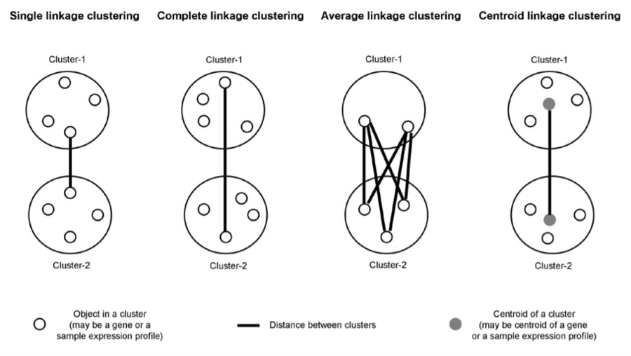

https://www.mrc-lmb.cam.ac.uk/genomes/madanm/microarray/chapter-final.pdf

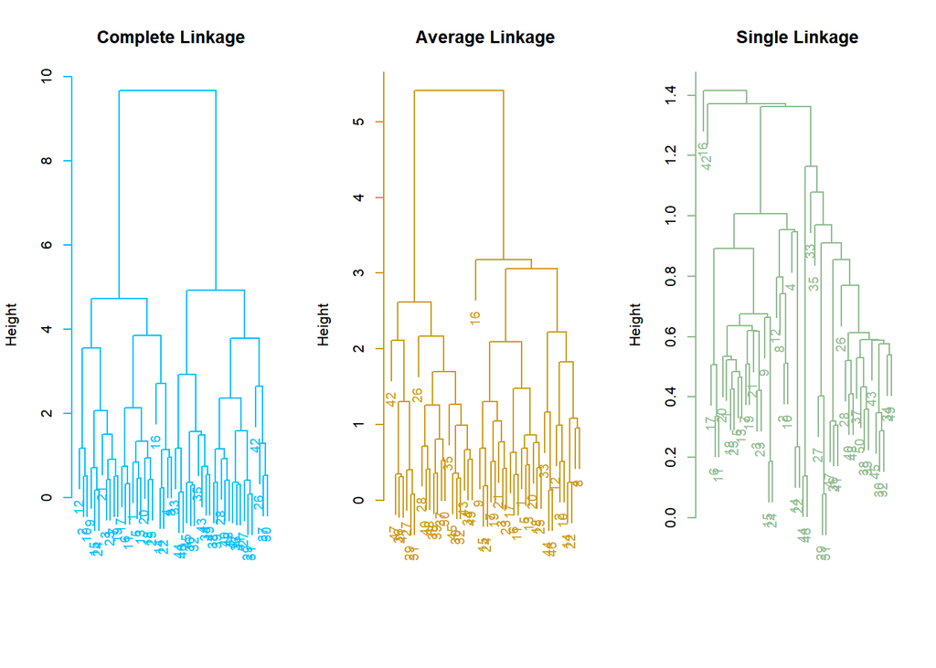

```r
par(mfrow=c(1,3))
plot(hc.complete ,main="Complete Linkage ", xlab="", sub="",
cex=.9, col = "deepskyblue") # produces a cleaner plot that is easy to follow

plot(hc.average , main="Average Linkage", xlab="", sub="",
cex=.9, col = "goldenrod3")

plot(hc.single , main="Single Linkage", xlab="", sub="",
cex=.9, col = "darkseagreen") # produces branches for every single observation. Not the most comprehensive heirachrical plotting method
```

To determine the cluster labels for each observation associated with a given cut of the dendrogram, we can use the **cutree()** function:

```r
cutree(hc.complete , 2) # Shows complete separation of clusters classes
```

```
##  [1] 1 1 1 1 1 1 1 1 1 1 1 1 1 1 1 1 1 1 1 1 1 1 1 1 1 2 2 2 2 2 2 2 2 2 2 2 2 2
## [39] 2 2 2 2 2 2 2 2 2 2 2 2
```

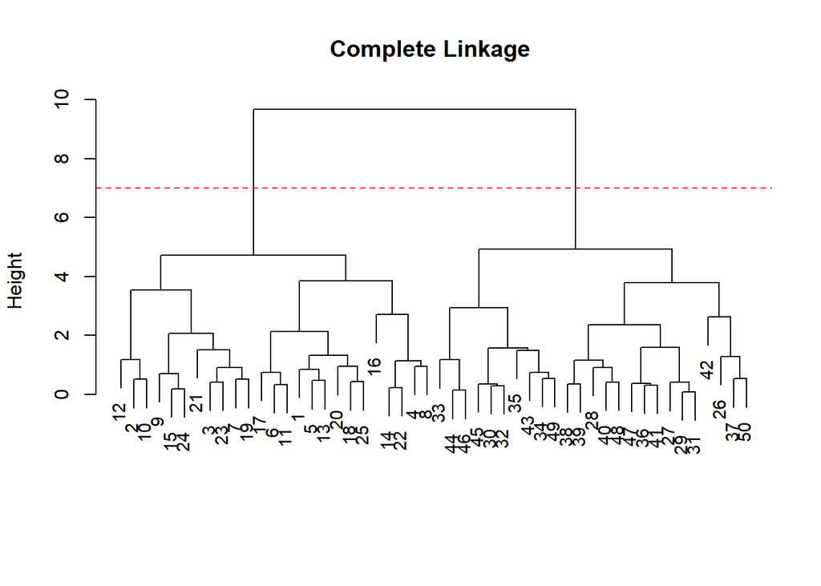

```r
plot(hc.complete ,main="Complete Linkage ", xlab="", sub="",
cex=.9)
abline(h= 7, col = "red", lty = "dashed")
```

```r
cutree(hc.average , 2)
```

```
##  [1] 1 1 1 1 1 1 1 1 1 1 1 1 1 1 1 1 1 1 1 1 1 1 1 1 1 2 2 2 2 2 2 2 1 2 2 2 2 2
## [39] 2 2 2 2 2 1 2 1 2 2 2 2
```

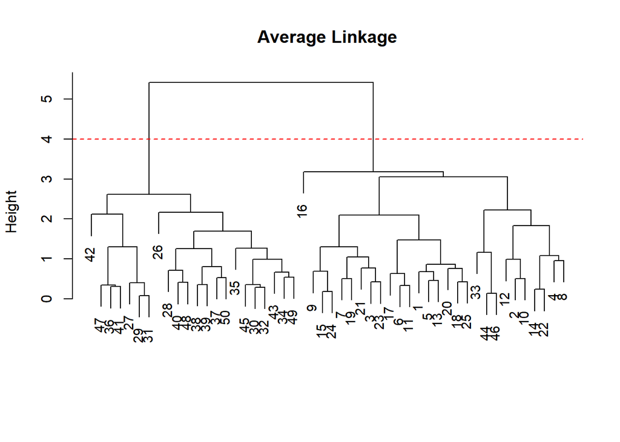

```r
plot(hc.average , main="Average Linkage", xlab="", sub="",
cex=.9)
abline(h= 4, col = "red", lty = "dashed")
```

```r
cutree(hc.single , 2)
```

```
##  [1] 1 1 1 1 1 1 1 1 1 1 1 1 1 1 1 2 1 1 1 1 1 1 1 1 1 1 1 1 1 1 1 1 1 1 1 1 1 1
## [39] 1 1 1 1 1 1 1 1 1 1 1 1
```

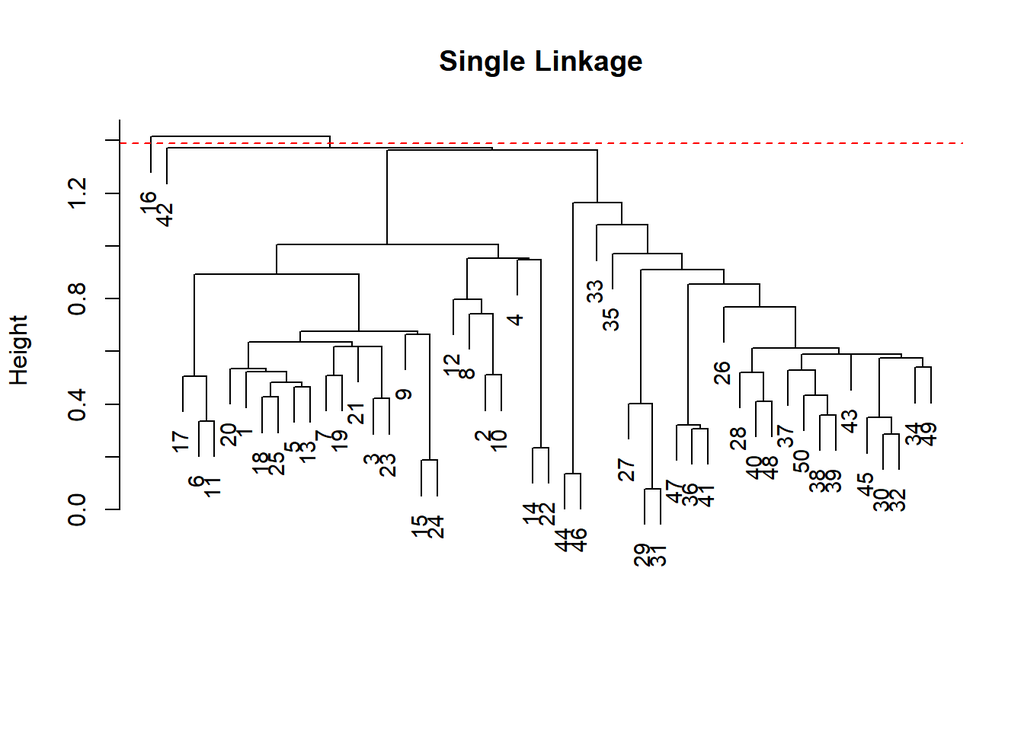

```r
plot(hc.single , main="Single Linkage", xlab="", sub="",
cex=.9)
abline(h= 1.39, col = "red", lty = "dashed")
```

For this data, complete and average linkage generally separate the observations into their correct groups. However, single linkage identifies one point as belonging to its own cluster. A more sensible answer is obtained when four clusters are selected, although there are still two singletons.

```r
cutree(hc.single , 4)
```

```
##  [1] 1 1 1 1 1 1 1 1 1 1 1 1 1 1 1 2 1 1 1 1 1 1 1 1 1 3 3 3 3 3 3 3 3 3 3 3 3 3
## [39] 3 3 3 4 3 3 3 3 3 3 3 3
```

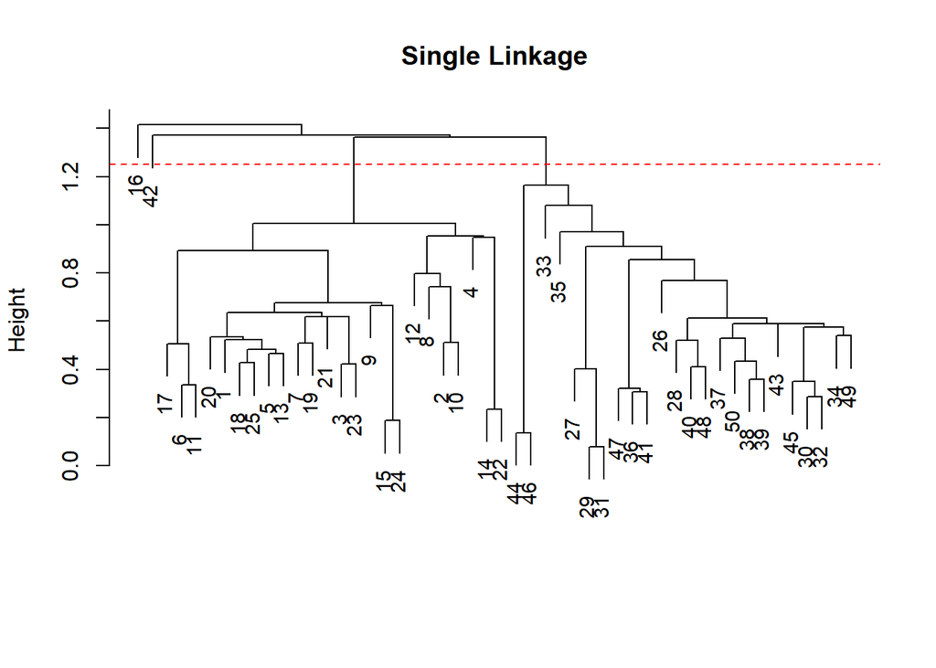

```r
plot(hc.single , main="Single Linkage", xlab="", sub="",
cex=.9)
abline(h= 1.25, col = "red", lty = "dashed")
```

To scale the variables before performing hierarchical clustering of the observations, we use the **scale()** function:

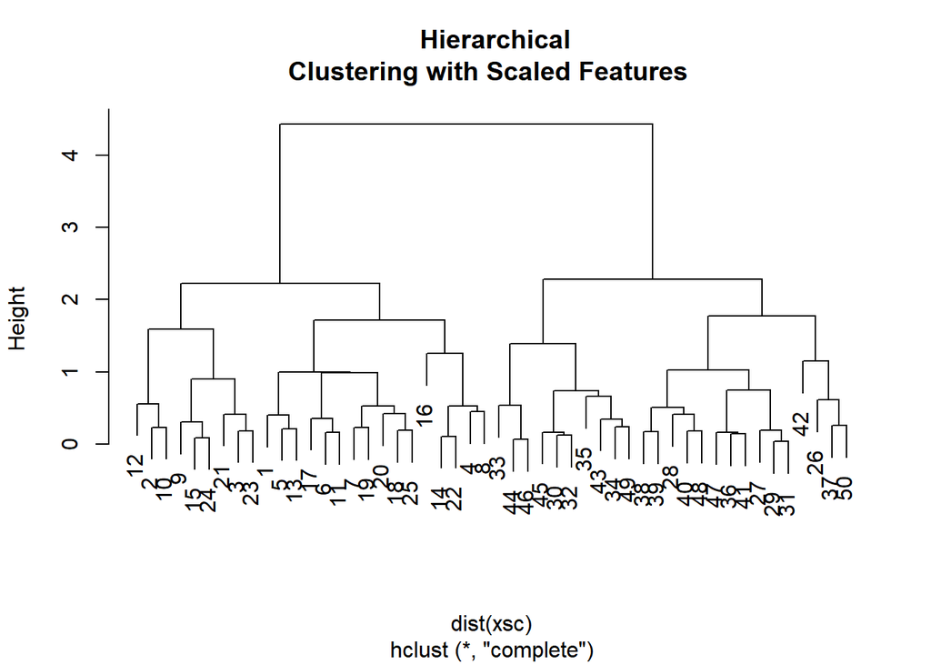

```r
xsc=scale(x)
plot(hclust(dist(xsc), method ="complete"), main=" Hierarchical
Clustering with Scaled Features ")
```

Correlation-based distance can be computed using the **as.dist()** function, which converts an arbitrary square symmetric matrix into a form that the **hclust()** function recognizes as a distance matrix. However, this only makes sense for data with at least three features since the absolute correlation between any two observations with measurements on two features is always 1. Hence, we will cluster a three-dimensional data set

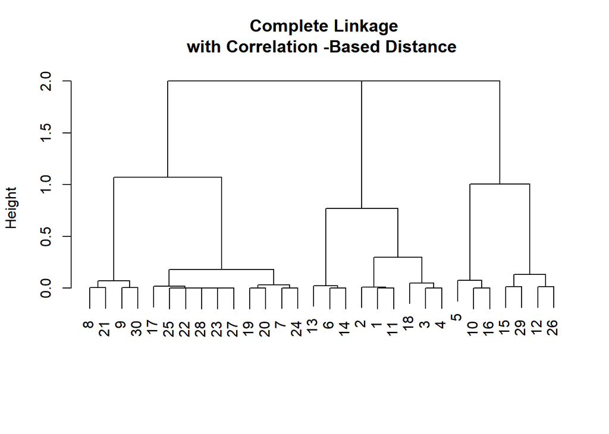

```r
x=matrix(rnorm (30*3), ncol=3)
dd=as.dist(1-cor(t(x)))
plot(hclust(dd, method ="complete"), main=" Complete Linkage
with Correlation -Based Distance", xlab="", sub ="")
```

## Applied Exercise No. 9

We will be using the **USArrests** data set from the *ISLR* library.

```r
library(ISLR)
```

#### a.) Using hierarchical clustering with complete linkage and Euclidean distance, cluster the states.

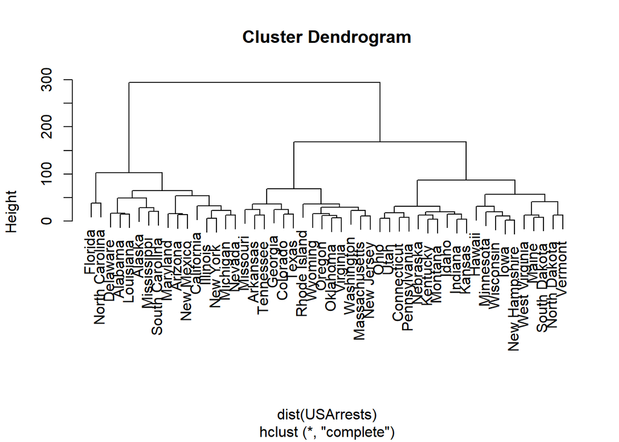

```r
set.seed(5082)
hcluster.complete <- hclust(dist(USArrests), method = "complete")
plot(hcluster.complete)
```

#### b.) Cut the dendrogram at a height that results in three distinct clusters. Which states belong to which clusters?

```r
# cutree(tree, k = NULL, h = NULL) , can speicify clusters (k) or dissimilarity
# height (h).
cutree(hcluster.complete, k = 3)
```

```
##        Alabama         Alaska        Arizona       Arkansas     California
##              1              1              1              2              1
##       Colorado    Connecticut       Delaware        Florida        Georgia
##              2              3              1              1              2
##         Hawaii          Idaho       Illinois        Indiana           Iowa
##              3              3              1              3              3
##         Kansas       Kentucky      Louisiana          Maine       Maryland
##              3              3              1              3              1
##  Massachusetts       Michigan      Minnesota    Mississippi       Missouri
##              2              1              3              1              2
##        Montana       Nebraska         Nevada  New Hampshire     New Jersey
##              3              3              1              3              2
##     New Mexico       New York North Carolina   North Dakota           Ohio
##              1              1              1              3              3
##       Oklahoma         Oregon   Pennsylvania   Rhode Island South Carolina
##              2              2              3              2              1
##   South Dakota      Tennessee          Texas           Utah        Vermont
##              3              2              2              3              3
##       Virginia     Washington  West Virginia      Wisconsin        Wyoming
##              2              2              3              3              2
```

```r
table(cutree(hc.complete, 3))
```

```
##
##  1  2  3
## 25 15 10
```

#### c.) Hierarchically cluster the states using complete linkage and Euclidean distance, after scaling the variables to have standard deviation one.

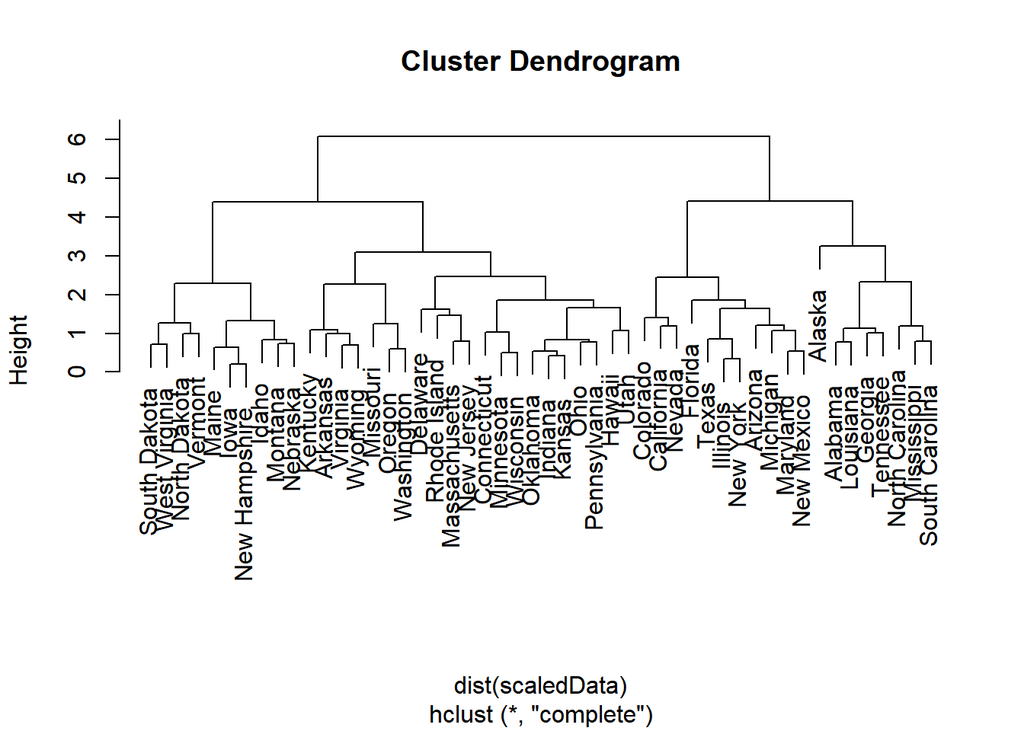

```r
# First we scale the data -- similar to PCR
scaledData <- scale(USArrests)
hscaled.complete <- hclust(dist(scaledData), method = "complete")
plot(hscaled.complete)
```

#### d.) What effect does scaling the variables have on the hierarchical clustering obtained? In your opinion, should the variables be scaled before the inter-observation dissimilarities are computed? Provide a justification for your answer.

```r
cutree(hscaled.complete, 3)
```

```
##        Alabama         Alaska        Arizona       Arkansas     California
##              1              1              2              3              2
##       Colorado    Connecticut       Delaware        Florida        Georgia
##              2              3              3              2              1
##         Hawaii          Idaho       Illinois        Indiana           Iowa
##              3              3              2              3              3
##         Kansas       Kentucky      Louisiana          Maine       Maryland
##              3              3              1              3              2
##  Massachusetts       Michigan      Minnesota    Mississippi       Missouri
##              3              2              3              1              3
##        Montana       Nebraska         Nevada  New Hampshire     New Jersey
##              3              3              2              3              3
##     New Mexico       New York North Carolina   North Dakota           Ohio
##              2              2              1              3              3
##       Oklahoma         Oregon   Pennsylvania   Rhode Island South Carolina
##              3              3              3              3              1
##   South Dakota      Tennessee          Texas           Utah        Vermont
##              3              1              2              3              3
##       Virginia     Washington  West Virginia      Wisconsin        Wyoming
##              3              3              3              3              3
```

```r
table(cutree(hscaled.complete, 3))
```

```
##
##  1  2  3
##  8 11 31
```

We can compare the difference between scaled and unscaled versions.

```r
table(cutree(hscaled.complete, 3), cutree(hcluster.complete, 3))
```

```
##
##      1  2  3
##   1  6  2  0
##   2  9  2  0
##   3  1 10 20
```

Observations from scaling the variables:

- The max height of the dendrogram obtained from hierarchical clustering becomes smaller.
- From a cursory glance, it doesn’t effect the bushiness of the tree obtained.
- Affects the clusters obtained from cutting the dendrogram into 3 clusters.

The data should be standardized because the data measured has different units (UrbanPop compared to other three columns).

## References

- Babu, M. M., & Grant, R. (n.d.). Computational Genomics. Horizon Press.